# Data Tidak Stasioner

Author

Windi Pangesti

Published

September 21, 2025

```r
library(ggplot2)
library(tsibble)
library(tseries)
library(MASS)
```

```r
set.seed(8990)
```

## Stasioner dalam Rataan dan Ragam

Pada dasarnya, pembangkitan data ARIMA akan menghasilkan data yang stasioner dalam rataan dan ragam karena akan mengikuti fungsi *default*-nya yang mengikuti pembangkitan bilangan acak normal dengan `mean=0` dan `ragam=1` .

```r
stas <- arima.sim(n=200, list(order=c(1,0,1),ar= 0.2, ma=0.2),mean=12)
```

### Plot *Time Series*

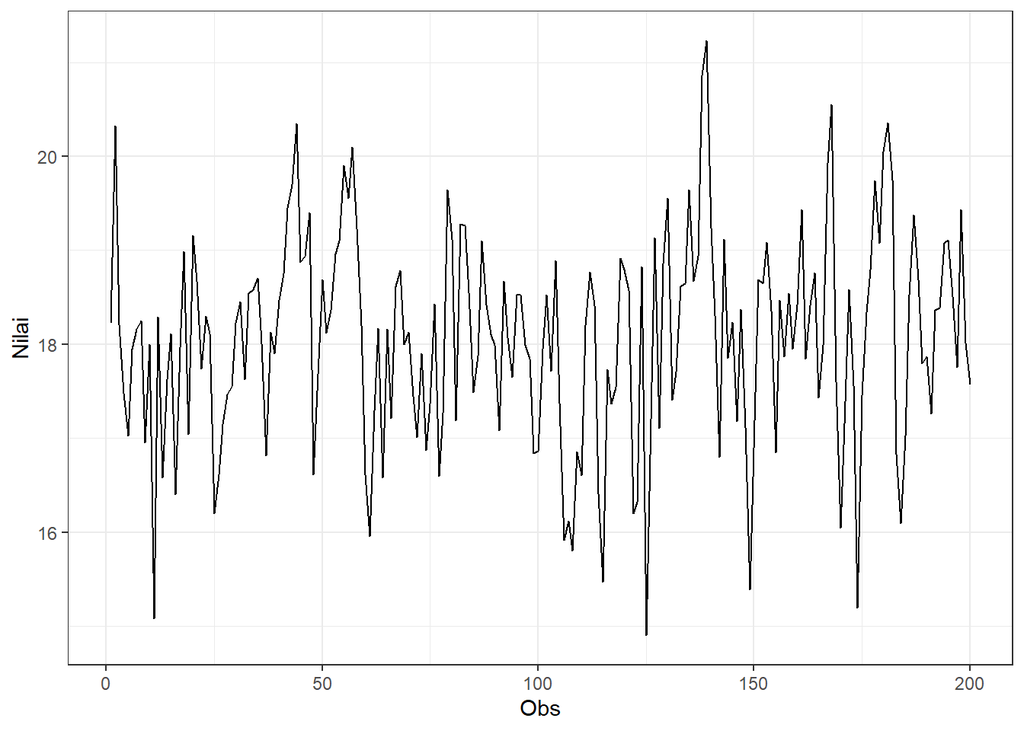

```r
plot_stas <- stas |> as_tsibble() |>
  ggplot(aes(x = index, y = value)) + geom_line() + theme_bw() +
  xlab("Obs") + ylab("Nilai")
plot_stas
```

```r
mean(stas)
```

```
[1] 18.06022
```

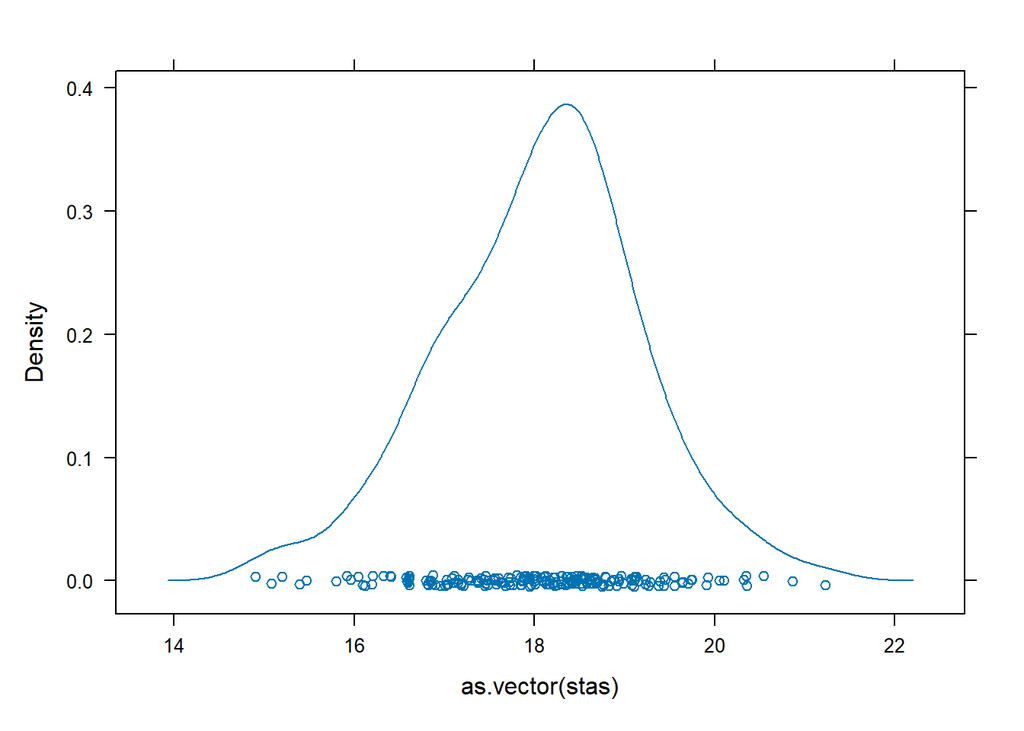

```r
lattice::densityplot(as.vector(stas))
```

Plot deret waktu di atas menunjukkan bahwa data stasioner dalam rataan, ditandai dengan data yang menyebar di sekitar nilai tengahnya (18) dan stasioner dalam ragam, ditandai dengan data berfluktuasi pada rentang yang relatif sama sepanjang waktu.

### Plot ACF

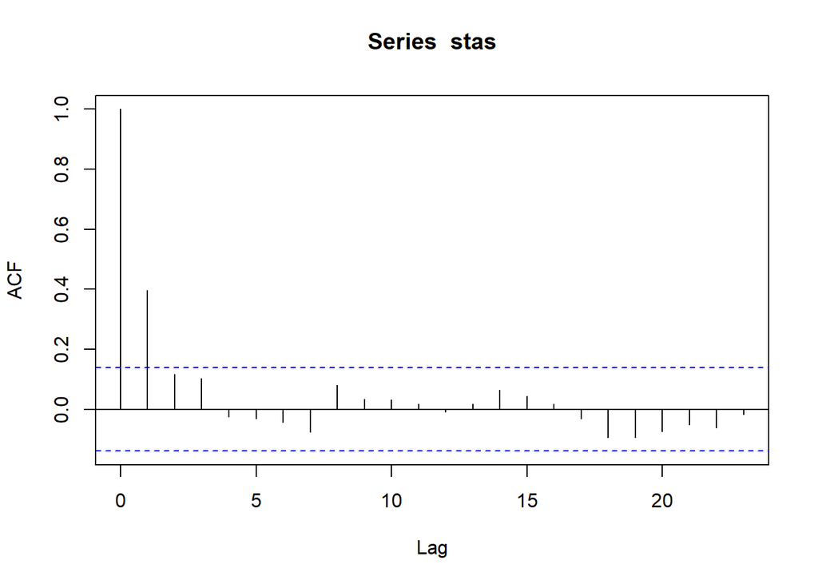

```r
acf(stas)
```

### Uji ADF

Uji ADF (Augmented Dickey–Fuller) adalah uji statistik yang digunakan untuk memeriksa apakah suatu deret waktu stasioner dalam rataan.

```r
tseries::adf.test(stas)
```

```
    Augmented Dickey-Fuller Test

data:  stas
Dickey-Fuller = -5.5322, Lag order = 5, p-value = 0.01
alternative hypothesis: stationary
```

$H_0$ : Data tidak stasioner dalam rataan

$H_1$ : Data stasioner dalam rataan

Berdasarkan uji ADF tersebut, didapat *p-value* sebesar 0.01 yang lebih kecil dari taraf nyata 5% sehingga tolak $H_0$ dan menandakan bahwa data **stasioner dalam rataan**. Hal ini sesuai dengan hasil eksplorasi menggunakan plot time series dan plot ACF.

### Plot Box-Cox

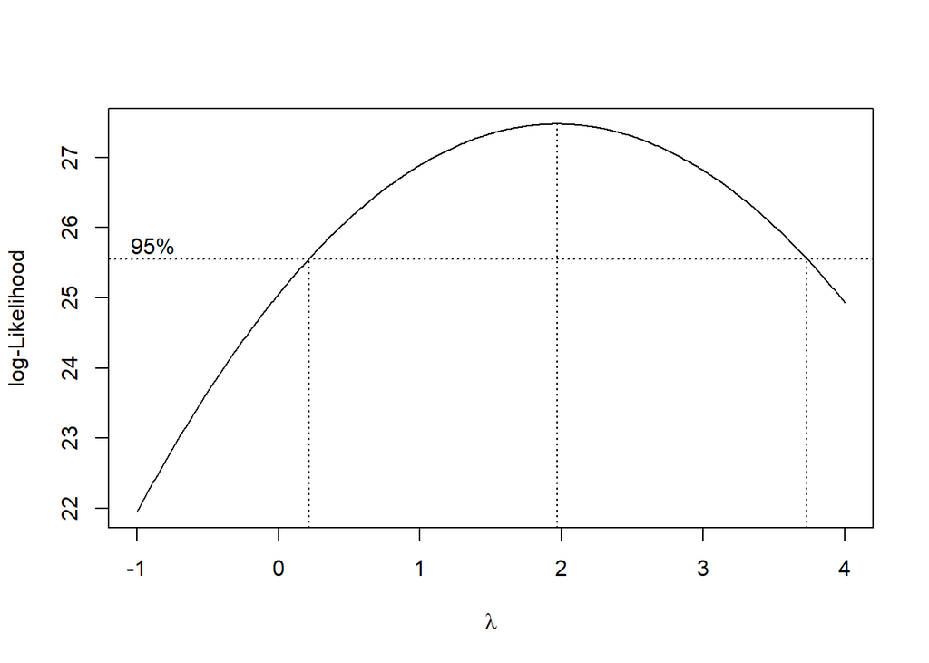

```r
index <- seq(1:200)

# Box-Cox
bc <- boxcox(
  stas ~ index,
  lambda = seq(-1, 4, by = 0.01)
)
```

```r
# Nilai lambda optimum
lambda <- bc$x[which.max(bc$y)]
lambda
```

```
[1] 1.97
```

```r
# Selang kepercayaan 95% untuk lambda
ci_lambda <- bc$x[bc$y > max(bc$y) - 0.5 * qchisq(0.95, 1)]

# Batas bawah dan batas atas
ci_lower <- min(ci_lambda)
ci_upper <- max(ci_lambda)

c(Batas_Bawah = ci_lower, Batas_Atas = ci_upper)
```

```
Batas_Bawah  Batas_Atas
       0.22        3.73
```

Gambar di atas menunjukkan nilai λ optimum (rounded value) sebesar **1,97** dan selang kepercayaan 95% nilai memiliki batas bawah **0,22** dan batas atas **3,73**. Selang tersebut memuat nilai satu sehingga dapat dikatakan bahwa data bangkitan **stasioner dalam ragam**.

> **Catatan:**  
> Fungsi `boxcox()` di R tidak dapat digunakan langsung pada data yang mengandung nilai nol atau negatif, meskipun hanya untuk tujuan estimasi λ. Hal ini karena perhitungan log-likelihood dalam Box–Cox mensyaratkan seluruh data bernilai positif.Jika dataset mengandung nilai nol atau negatif, maka perlu ditambahkan suatu konstanta positif pada seluruh data sehingga semua nilainya menjadi positif sebelum dilakukan analisis Box–Cox.

### Partisi Data Deret Waktu

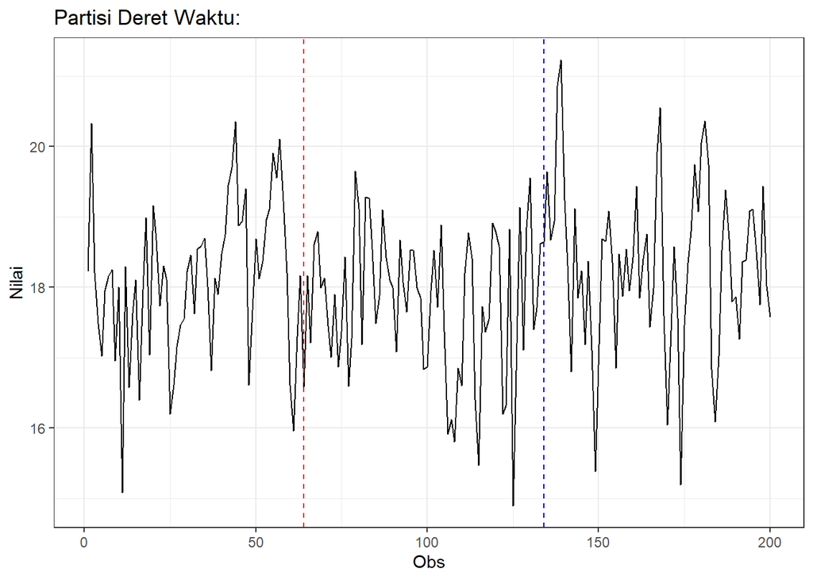

```r
library(ggplot2)
library(tsibble)

plot_stas <- stas |>
  as_tsibble() |>
  ggplot(aes(x = index, y = value)) +
  geom_line() +
  theme_bw() +
  xlab("Obs") +
  ylab("Nilai") +

  # Tambahkan garis batas
  geom_vline(xintercept = 64, linetype = "dashed", color = "red") +
  geom_vline(xintercept = 134, linetype = "dashed", color = "blue") +
  ggtitle("Partisi Deret Waktu:")

plot_stas
```

```r
dt_stas1 <- stas[1:67] |> ts()

#rata-rata
mean(dt_stas1)
```

```
[1] 18.08483
```

```r
#varians
var(dt_stas1)
```

```
[1] 1.141982
```

#### Plot Time Series

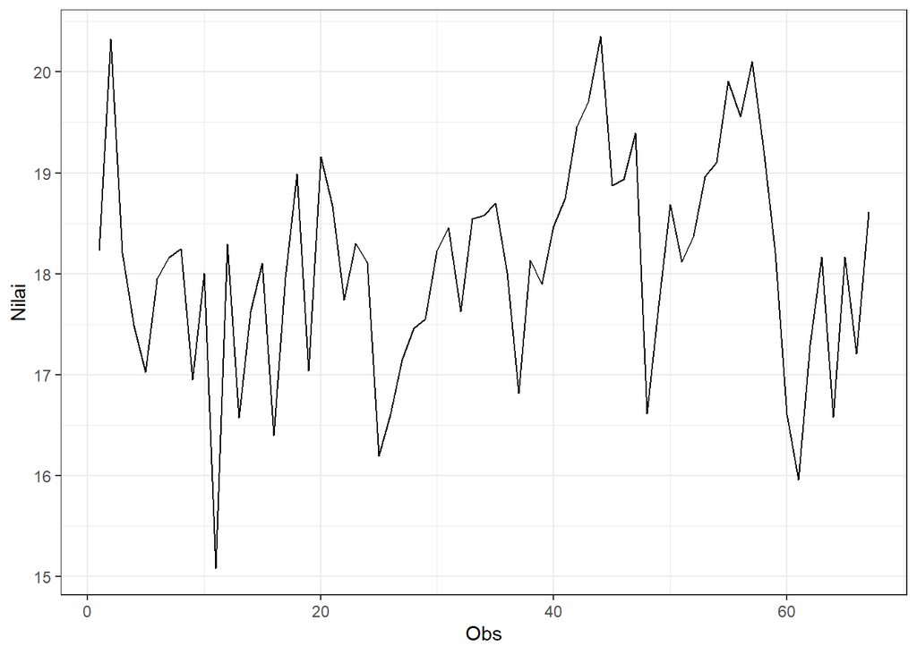

```r
dt_stas1 |> as_tsibble() |>
  ggplot(aes(x = index, y = value)) +
  geom_line() + theme_bw() +
  xlab("Obs") + ylab("Nilai")
```

Plot deret waktu di atas menunjukkan bahwa data stasioner dalam rataan, ditandai dengan data yang menyebar di sekitar nilai tengahnya (18) dan stasioner dalam ragam, ditandai dengan data berfluktuasi pada rentang yang relatif sama sepanjang waktu.

#### Plot ACF

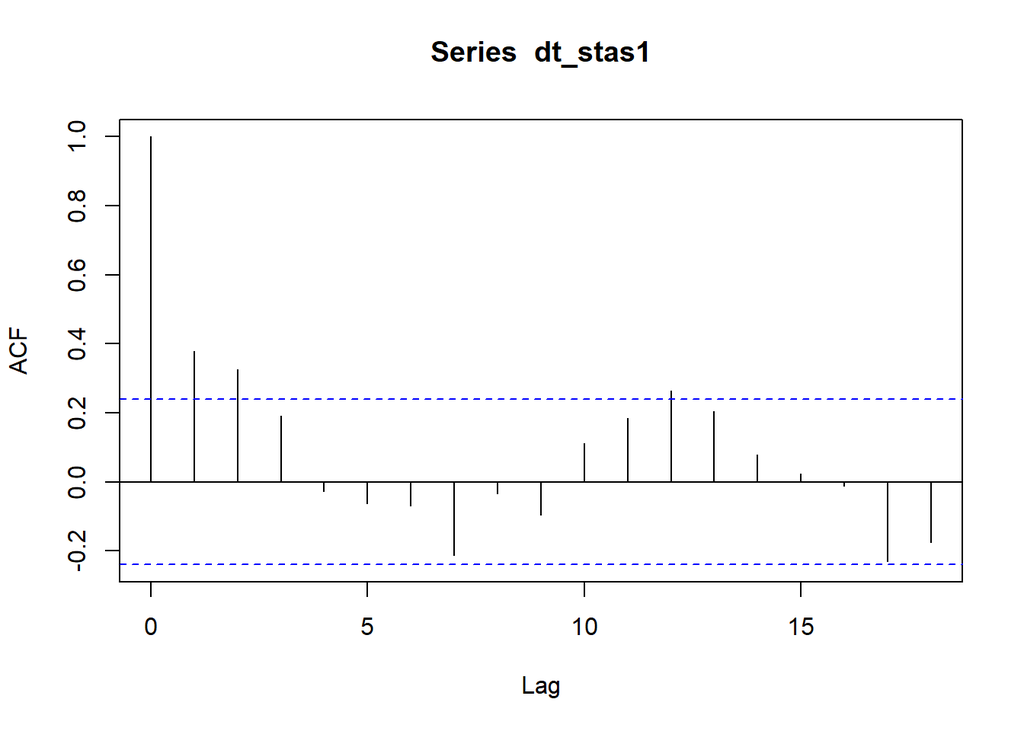

```r
acf(dt_stas1)
```

Berdasarkan plot ACF, terlihat bahwa plot ACF pada data tersebut cenderung *tails off* dan membentuk gelombang sinus.

#### Uji ADF

```r
tseries::adf.test(dt_stas1)
```

```
    Augmented Dickey-Fuller Test

data:  dt_stas1
Dickey-Fuller = -3.5663, Lag order = 4, p-value = 0.043
alternative hypothesis: stationary
```

$H_0$ : Data tidak stasioner dalam rataan

$H_1$ : Data stasioner dalam rataan

Berdasarkan uji ADF tersebut, didapat *p-value* sebesar 0.043 yang lebih kecil dari taraf nyata 5% sehingga tolak $H_0$ dan menandakan bahwa data **stasioner dalam rataan**. Hal ini sesuai dengan hasil eksplorasi menggunakan plot time series dan plot ACF.

#### Plot Boxcox

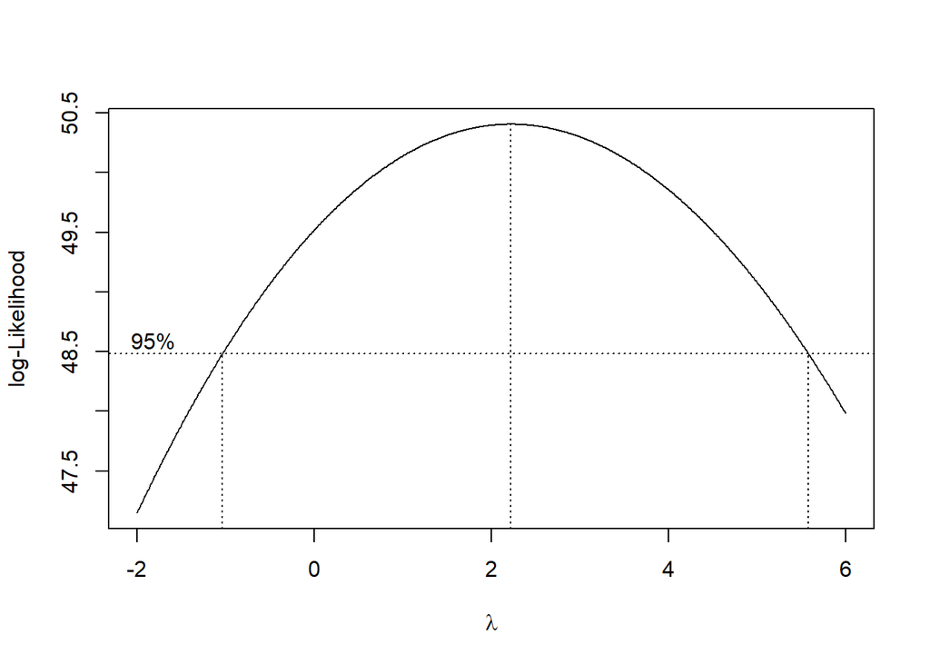

```r
index <- seq(1, 67)

# Box-Cox
bc <- boxcox(
  dt_stas1 ~ index,
  lambda = seq(-2, 6, by = 0.01)
)
```

```r
# Nilai lambda optimum (dibulatkan)
lambda <- bc$x[which.max(bc$y)]
lambda
```

```
[1] 2.22
```

```r
# Selang kepercayaan 95% untuk lambda
ci_lambda <- bc$x[bc$y > max(bc$y) - 0.5 * qchisq(0.95, 1)]

# Batas bawah dan batas atas
ci_lower <- min(ci_lambda)
ci_upper <- max(ci_lambda)

c(Batas_Bawah = ci_lower, Batas_Atas = ci_upper)
```

```
Batas_Bawah  Batas_Atas
      -1.03        5.57
```

Gambar di atas menunjukkan nilai *rounded value* ($\lambda$) optimum sebesar **2,2** dan pada selang kepercayaan 95% nilai memiliki batas bawah **-1,03** dan batas atas **5,57**. Selang tersebut memuat nilai satu sehingga dapat dikatakan bahwa data bangkitan stasioner dalam ragam.

### Bagian 2 : observasi 1 - 134

```r
dt_stas2 <- stas[1:134] |> ts()
mean(dt_stas2)
```

```
[1] 17.93724
```

```r
var(dt_stas2)
```

```
[1] 1.128205
```

#### Plot Time Series

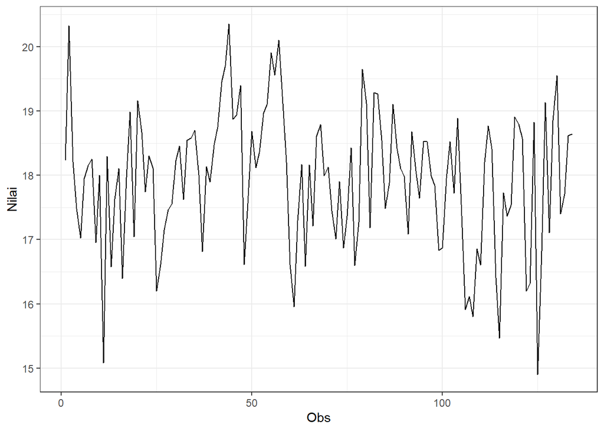

```r
dt_stas2 |> as_tsibble() |>
  ggplot(aes(x = index, y = value)) +
  geom_line() + theme_bw() +
  xlab("Obs") + ylab("Nilai")
```

Plot deret waktu di atas menunjukkan bahwa data stasioner dalam rataan, ditandai dengan data yang menyebar di sekitar nilai tengahnya (18) dan stasioner dalam ragam, ditandai dengan data berfluktuasi pada rentang yang relatif sama sepanjang waktu.

#### Plot ACF

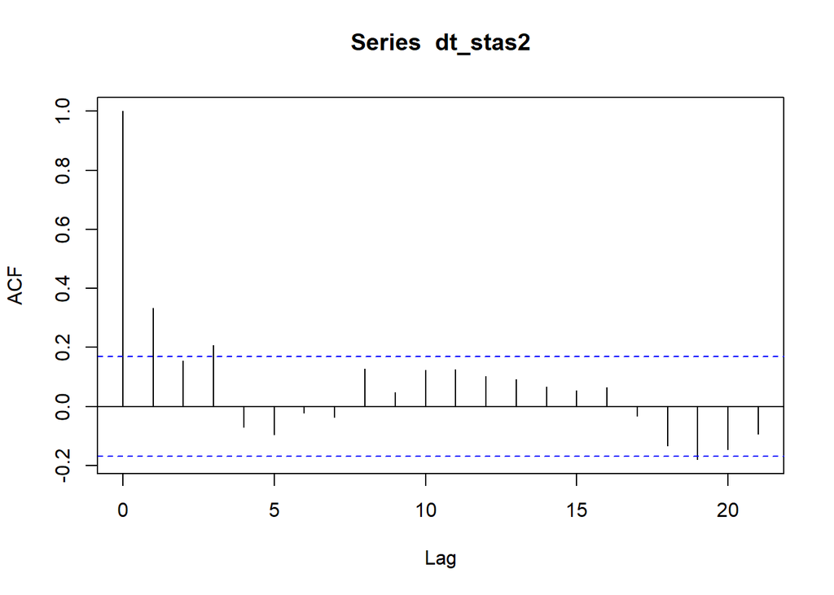

```r
acf(dt_stas2)
```

Berdasarkan plot ACF, terlihat bahwa plot ACF pada data tersebut cut off

#### Uji ADF

```r
adf.test(dt_stas2)
```

```
    Augmented Dickey-Fuller Test

data:  dt_stas2
Dickey-Fuller = -4.4004, Lag order = 5, p-value = 0.01
alternative hypothesis: stationary
```

$H_0$ : Data tidak stasioner dalam rataan

$H_1$ : Data stasioner dalam rataan

Berdasarkan uji ADF tersebut, didapat *p-value* sebesar 0.01 yang lebih kecil dari taraf nyata 5% sehingga tolak $H_0$ dan menandakan bahwa **data stasioner dalam rataan**. Hal ini sesuai dengan hasil eksplorasi menggunakan plot time series dan plot ACF.

#### Plot Boxcox

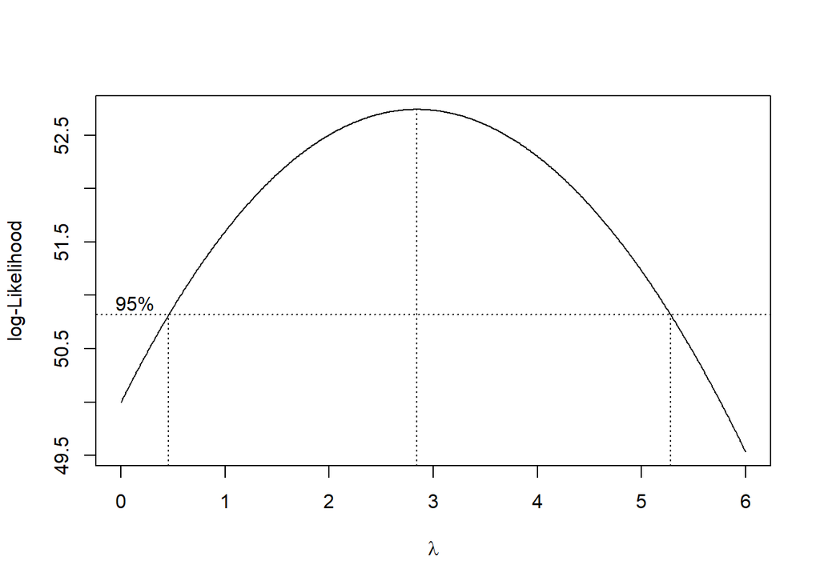

```r
index <- seq(1, 134)

# Box-Cox
bc <- boxcox(
  dt_stas2 ~ index,
  lambda = seq(0, 6, by = 0.01)
)
```

```r
# Nilai lambda optimum
lambda <- bc$x[which.max(bc$y)]
lambda
```

```
[1] 2.84
```

```r
# Selang kepercayaan 95% untuk lambda
ci_lambda <- bc$x[bc$y > max(bc$y) - 0.5 * qchisq(0.95, 1)]

# Batas bawah dan batas atas
ci_lower <- min(ci_lambda)
ci_upper <- max(ci_lambda)

c(Batas_Bawah = ci_lower, Batas_Atas = ci_upper)
```

```
Batas_Bawah  Batas_Atas
       0.47        5.27
```

## Tidak Stasioner dalam Rataan, Stasioner dalam Ragam

Bagaimana cara mensimulasikan data dengan tren tertentu?

Kunci dari simulasi tersebut berada di $Y_{t}-Y_{t-1}$, atau *first difference*, atau selisih antara observasi di waktu ke $t$ dan observasi sebelumnya. Jika suatu deret waktu memiliki tren naik, misal, maka selisih tersebut akan positif. Sebaliknya, jika suatu deret memiliki tren turun, maka selisih akan negatif. Jika suatu deret stasioner, selisih akan memiliki rata-rata nol.

Ini dapat diilustrasikan dengan fungsi `cumsum`. `cumsum` adalah jumlah kumulatif. Untuk mengerti logika dari pengunaan jumlah kumulatif, bayangkan ada deret waktu dengan nilai awal $c$:

$$Y_1 = c$$

Lalu definsikan $d_i$, di mana $i = 2, 3, \ldots$ sebagai selisih observasi ke-i dengan observasi sebelumnya:

$$d_i = Y_i-Y_{i-1}$$

Perhatikan bahwa:

$$\begin{aligned}
Y_3-Y_{1} & = d_3+d_2\\
&= Y_3-Y_2+Y_2-Y_1
\end{aligned}$$

Cukup jelas bahwa sifat tersebut berarti:

$$\begin{aligned}
Y_t-Y_1 &= \sum_{i=2}^t d_i\\
Y_t &= Y_1 + \sum_{i=2}^t d_i
\end{aligned}$$

Atau, amatan di waktu ke $t$ dapat ditemukan dari menambahkan amatan ke-1 dengan jumlah kumulatif perbedaan $d_i$ sampai di waktu ke-t. Kode di bawah membuat data dengan proses tersebut. Ada tiga skenario, yaitu:

1. Selisih antara observasi dan observasi sebelumnya nol
2. Selisih antara observasi dan observasi sebelumnya positif
3. Selisih antara observasi dan observasi sebelumnya negatif

Dengan nilai awal 1 dan komponen $e_t$ menyebar normal.

```r
# Simulasi deret waktu dengan tren berbeda
# Tanpa tren
notrend <- 1 + cumsum(rep(0, 100)) + rnorm(100) |> ts()

# Tren naik
postrend <- 1 + cumsum(rep(0.2, 100)) + rnorm(100) |> ts()

# Tren turun
negtrend <- 1 + cumsum(rep(-0.2, 100)) + rnorm(100) |> ts()
```

Hasil yang muncul dapat di-plot (note, untuk plotting ini digunakan `ggplot2`; `ts.plot()` dapat digunakan - ini tergantung preferensi saja):

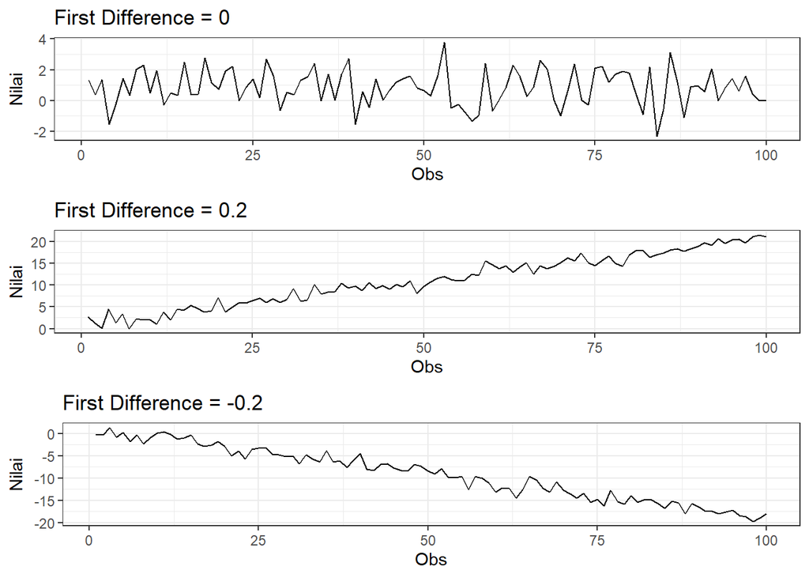

```r
plot_notrend <- notrend |> as_tsibble() |>
  ggplot(aes(x = index, y = value)) + geom_line() + theme_bw() +
  xlab("Obs") + ylab("Nilai") + ggtitle("First Difference = 0")
plot_postrend <- postrend |> as_tsibble() |>
  ggplot(aes(x = index, y = value)) + geom_line() + theme_bw() +
  xlab("Obs") + ylab("Nilai") + ggtitle("First Difference = 0.2")
plot_negtrend <- negtrend |> as_tsibble() |>
  ggplot(aes(x = index, y = value)) + geom_line() + theme_bw() +
  xlab("Obs") + ylab("Nilai") + ggtitle("First Difference = -0.2")

ggpubr::ggarrange(plot_notrend, plot_postrend, plot_negtrend, nrow = 3)
```

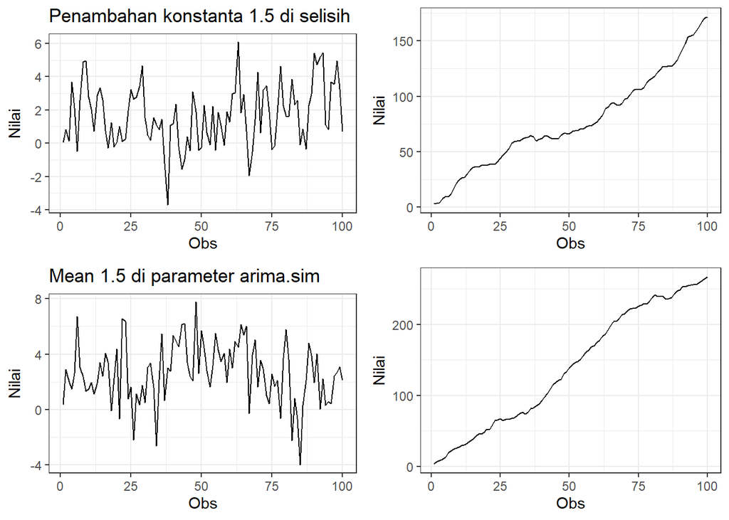

```r
startSpot <- 3

# Cara 1: tambah konstanta 1.5 di selisih
dt <- ts(arima.sim(n = 100,
                   list(order = c(1,0,1), ar = 0.2, ma = 0.2),
                   sd = 2) + 1.5)
yt <- ts(startSpot + cumsum(dt))

# Cara 2: gunakan mean = 1.5 di arima.sim
dt_alt <- ts(arima.sim(n = 100,
                       list(order = c(1,0,1), ar = 0.2, ma = 0.2),
                       mean = 1.5, sd = 2))
yt_alt <- ts(startSpot + cumsum(dt_alt))

# Plot hasil simulasi
plot_dt <- dt |> as_tsibble() |>
  ggplot(aes(x = index, y = value)) + geom_line() + theme_bw() +
  xlab("Obs") + ylab("Nilai") + ggtitle("Penambahan konstanta 1.5 di selisih")
plot_yt <- yt |> as_tsibble() |>
  ggplot(aes(x = index, y = value)) + geom_line() + theme_bw() +
  xlab("Obs") + ylab("Nilai")
plot_dt_alt <- dt_alt |> as_tsibble() |>
  ggplot(aes(x = index, y = value)) + geom_line() + theme_bw() +
  xlab("Obs") + ylab("Nilai") + ggtitle("Mean 1.5 di parameter arima.sim")
plot_yt_alt <- yt_alt |> as_tsibble() |>
  ggplot(aes(x = index, y = value)) + geom_line() + theme_bw() +
  xlab("Obs") + ylab("Nilai")

# Gabungkan Plot
ggpubr::ggarrange(plot_dt, plot_yt, plot_dt_alt, plot_yt_alt)
```

Terlihat di contoh di atas bahwa menambahkan konstanta 1.5 pada hasil `arima.sim` beda dengan memasukkan parameter `mean = 1.5`.

### Data Bangkitan Baru

```r
set.seed(8990)
dt_alt <- arima.sim(n=200, list(order=c(1,0,1),ar=c(.2), ma=.2), mean=0.2, sd=0.5)  |> ts()
postrend <- startSpot + cumsum(dt_alt) |> ts()
```

### Plot Time Series

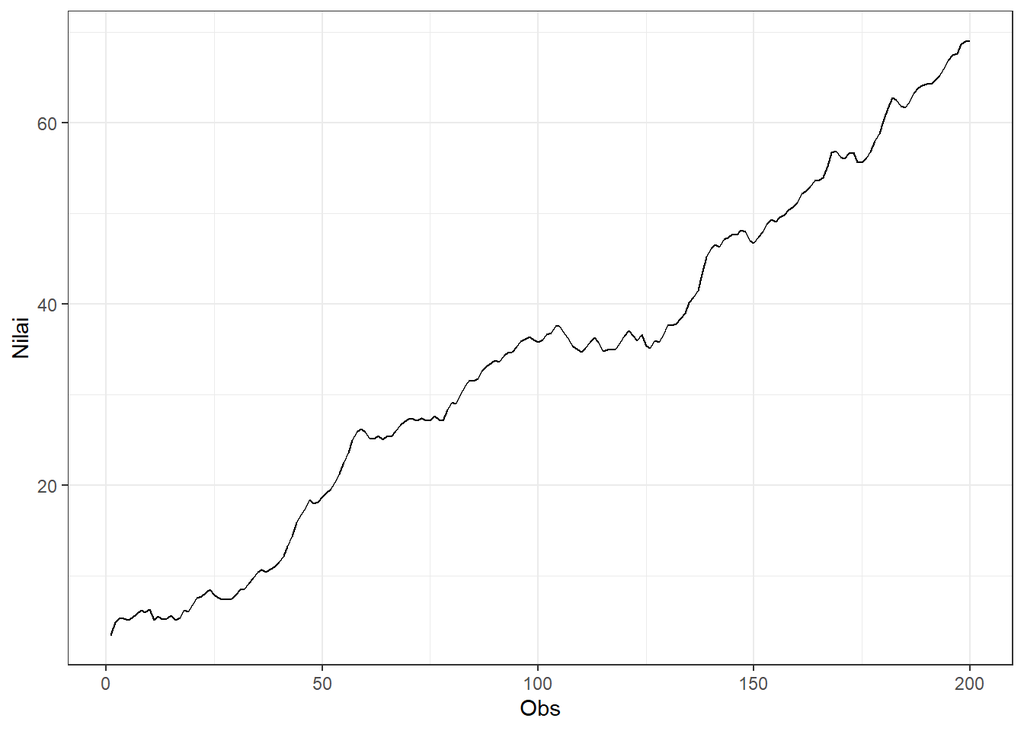

```r
postrend |> as_tsibble() |>
  ggplot(aes(x = index, y = value)) +
  geom_line() + theme_bw() +
  xlab("Obs") + ylab("Nilai")
```

```r
mean(postrend)
```

```
[1] 33.75305
```

```r
var(postrend)
```

```
[1] 341.6068
```

Berdasarkan plot time series tersebut, terlihat bahwa data tidak stasioner dalam rataan, ditandai dengan adanya kecenderungan (tren) positif, tetapi stasioner dalam ragam, ditandai dengan adanya lebar pita pada plot yang cenderung sama.

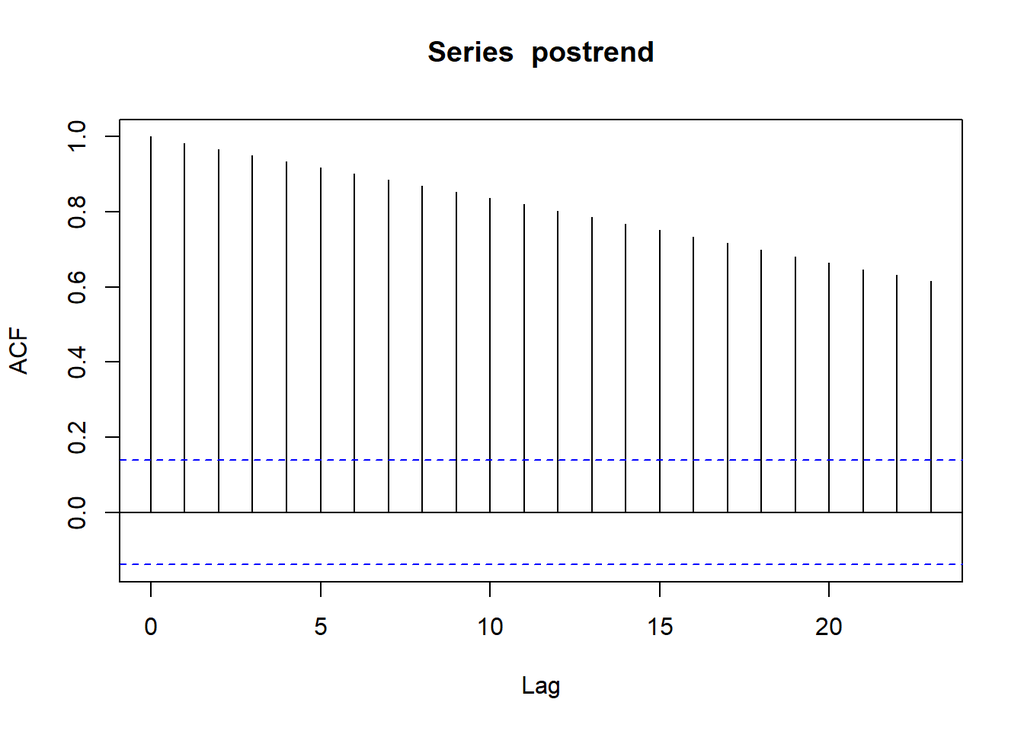

```r
acf(postrend)
```

Plot ACF `postrend` menunjukkan korelasi yang menurun secara perlahan pada banyak lag, sehingga menjadi indikasi kuat bahwa deret tidak stasioner.

### Uji ADF

```r
tseries::adf.test(postrend)
```

```
    Augmented Dickey-Fuller Test

data:  postrend
Dickey-Fuller = -1.9413, Lag order = 5, p-value = 0.6007
alternative hypothesis: stationary
```

Berdasarkan uji ADF tersebut, didapat *p-value* lebih besar dari taraf nyata 5% sehingga gagal tolak $H_0$ dan menandakan bahwa **data tidak stasioner dalam rataan**. Hal ini sesuai dengan hasil eksplorasi menggunakan plot time series dan plot ACF.

### Plot Box-Cox

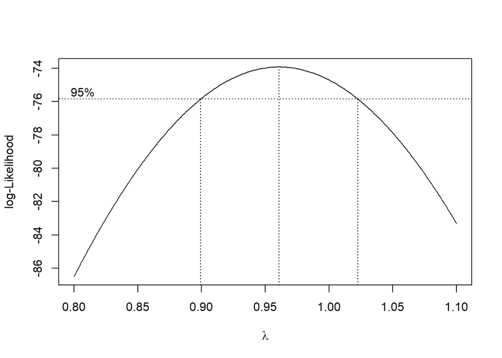

```r
index <- seq(1, 200)

# Uji Box-Cox
bc <- boxcox(
  postrend ~ index,
  lambda = seq(0.8, 1.1, by = 0.001)
)
```

```r
# Nilai lambda optimum
lambda <- bc$x[which.max(bc$y)]
lambda
```

```
[1] 0.961
```

```r
# Selang kepercayaan 95% untuk lambda
ci_lambda <- bc$x[bc$y > max(bc$y) - 0.5 * qchisq(0.95, 1)]

# Batas bawah dan batas atas
ci_lower <- min(ci_lambda)
ci_upper <- max(ci_lambda)

c(Batas_Bawah = ci_lower, Batas_Atas = ci_upper)
```

```
Batas_Bawah  Batas_Atas
      0.900       1.022
```

### Differencing

Dalam analisis deret waktu, differencing merupakan salah satu prosedur transformasi yang digunakan untuk memperoleh sifat stasioneritas dalam rataan. Metode ini dilakukan dengan menghitung selisih nilai observasi antar periode sehingga pola tren atau ketidakstasioneran dalam rataan dapat dieliminasi.

Secara umum, pembedaan pertama ditulis sebagai:

$$\nabla Y_t = Y_t - Y_{t-1}$$

Jika tren linier masih tersisa/ belum stasioner, dapat dilakukan differencing kedua:
$$\nabla^2 Y_t = \nabla (\nabla Y_t) = Y_t - 2Y_{t-1} + Y_{t-2}$$

Dengan cara ini, data yang awalnya tidak stasioner dapat ditransformasi menjadi stasioner sehingga bisa digunakan dalam pemodelan. Di dalam **R**, proses differencing dapat dilakukan dengan fungsi:

- `diff(y, differences = 1)` → untuk differencing pertama.
- `diff(y, differences = 2)` → untuk differencing kedua.

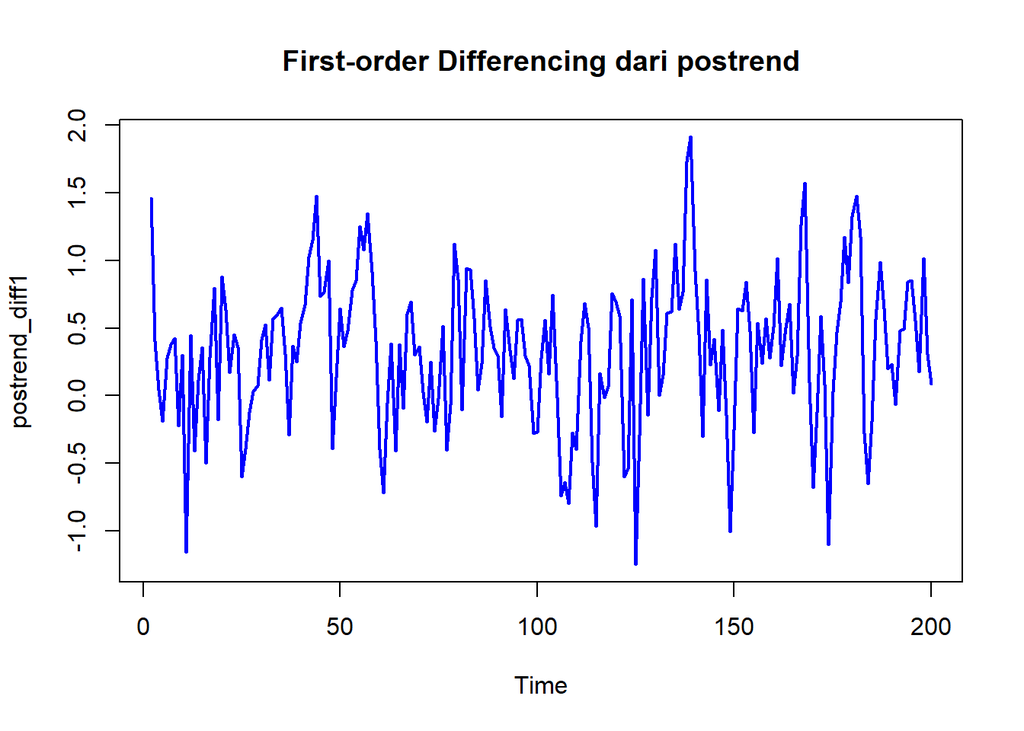

```r
# Differencing pertama pada postrend
postrend_diff1 <- diff(postrend, differences = 1)

# Plot hasil differencing
ts.plot(postrend_diff1,
        main = "First-order Differencing dari postrend",
        col = "blue", lwd = 2)
```

### Plot ACF

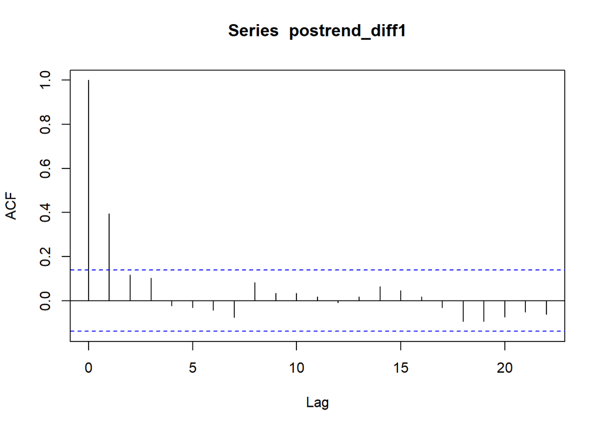

```r
acf(postrend_diff1)
```

### Uji ADF

```r
adf.test(postrend_diff1)
```

```
    Augmented Dickey-Fuller Test

data:  postrend_diff1
Dickey-Fuller = -5.52, Lag order = 5, p-value = 0.01
alternative hypothesis: stationary
```

Berdasarkan uji ADF tersebut, didapat *p-value* sebesar 0.01 yang lebih kecil dari taraf nyata 5% sehingga tolak $H_0$ dan menandakan bahwa **data sudah stasioner dalam rataan**. Hal ini sesuai dengan hasil eksplorasi menggunakan plot time series dan plot ACF.

### Partisi Data

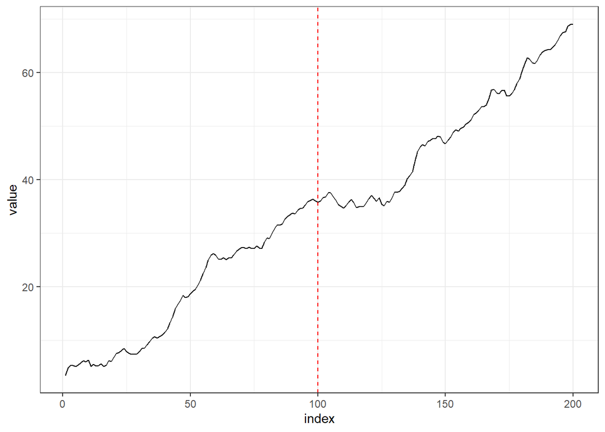

```r
postrend |>
  as_tsibble() |>
  ggplot(aes(x = index, y = value)) +
  geom_line() +
  geom_vline(xintercept = 100, linetype = "dashed", color = "red") +
  theme_bw()
```

#### Bagian 1 : observasi 1 - 100

```r
postrend1 <- postrend[1:100] |> ts()
mean(postrend1)
```

```
[1] 18.84534
```

```r
var(postrend1)
```

```
[1] 116.7756
```

#### Plot Time Series

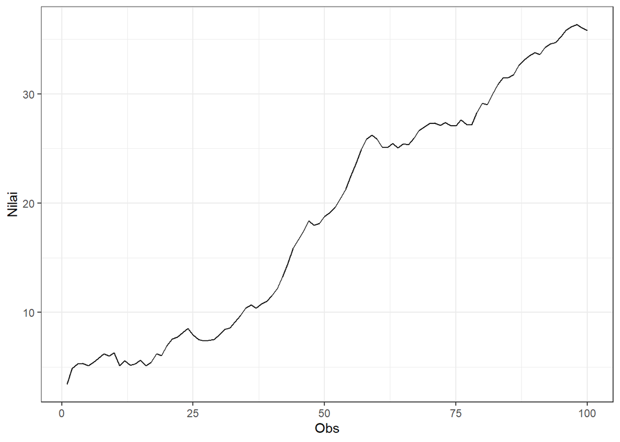

```r
postrend1 |> as_tsibble() |>
  ggplot(aes(x = index, y = value)) +
  geom_line()+theme_bw() +
  xlab("Obs") + ylab("Nilai")
```

#### Plot ACF

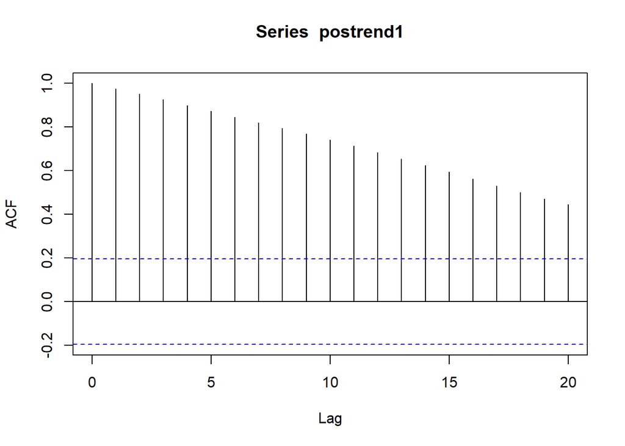

```r
acf(postrend1)
```

#### Uji ADF

```r
adf.test(postrend1)
```

```
    Augmented Dickey-Fuller Test

data:  postrend1
Dickey-Fuller = -2.2384, Lag order = 4, p-value = 0.4779
alternative hypothesis: stationary
```

#### Plot Boxcox

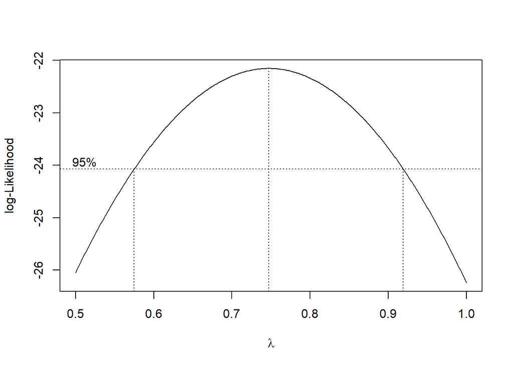

```r
index <- seq(1:100)

# Uji Box-Cox
bc <- boxcox(
  postrend1 ~ index,
  lambda = seq(0.5, 1, by = 0.001)
)
```

```r
# Nilai lambda optimum (dibulatkan)
lambda <- bc$x[which.max(bc$y)]
lambda
```

```
[1] 0.747
```

```r
# Selang kepercayaan 95% untuk lambda
ci_lambda <- bc$x[bc$y > max(bc$y) - 0.5 * qchisq(0.95, 1)]

# Batas bawah dan batas atas
ci_lower <- min(ci_lambda)
ci_upper <- max(ci_lambda)

c(Batas_Bawah = ci_lower, Batas_Atas = ci_upper)
```

```
Batas_Bawah  Batas_Atas
      0.575       0.919
```

## Tidak Stasioner dalam Ragam, Stasioner dalam Rataan

`arima.sim` memiliki parameter sd yang dapat di-set beda.

```r
set.seed(8090)
sd1 <- arima.sim(n=80, list(order=c(1,0,1),ar=c(.2), ma=.2), sd = 1)
sd5 <- arima.sim(n=120, list(order=c(1,0,1),ar=c(.2), ma=.2), sd = 5)
dtgab <- c(sd1,sd5) |> ts()
```

### Plot Time Series

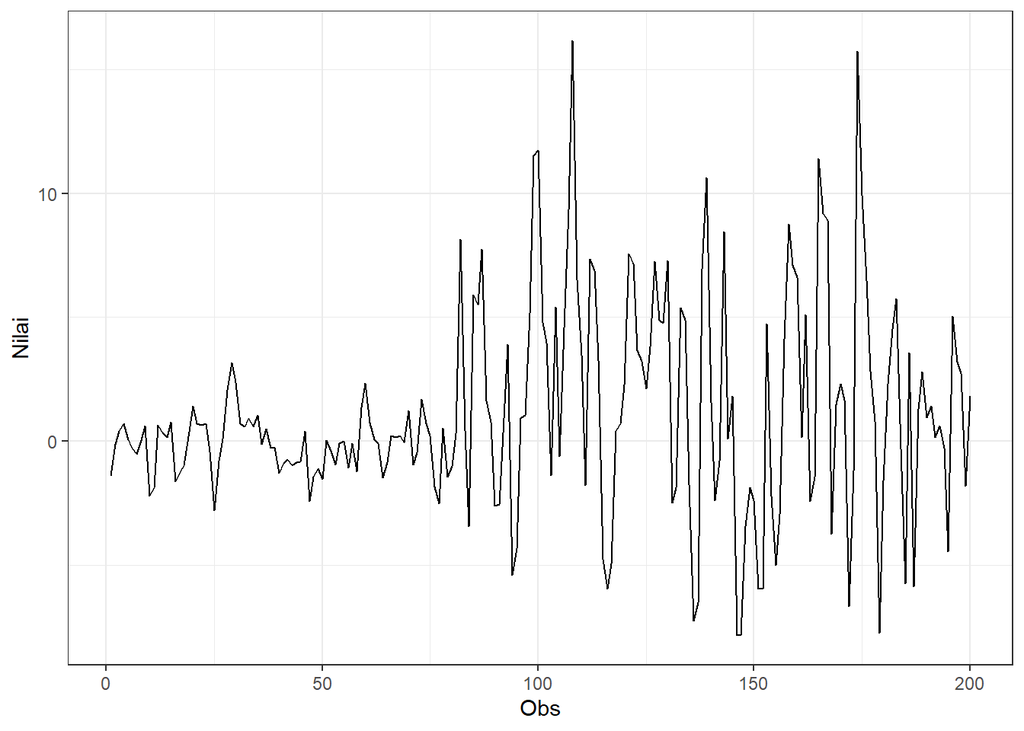

```r
dtgab |> as_tsibble() |>
  ggplot(aes(x = index, y = value)) +
  geom_line() + theme_bw() +
  xlab("Obs") + ylab("Nilai")
```

Berdasarkan plot deret waktu, data terlihat stasioner dalam rataan karena tidak menunjukkan adanya tren maupun pola musiman. Namun, data belum stasioner dalam ragam, yang ditunjukkan oleh adanya perbedaan besar-kecilnya fluktuasi pada plot.

### Plot ACF

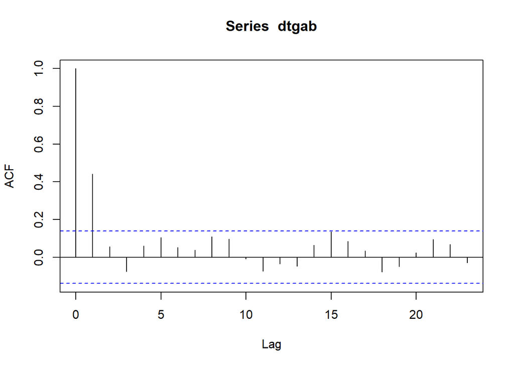

```r
acf(dtgab)
```

Berdasarkan plot ACF, terlihat bahwa data stasioner dalam rataan.

### Uji ADF

```r
adf.test(dtgab)
```

```
    Augmented Dickey-Fuller Test

data:  dtgab
Dickey-Fuller = -5.1553, Lag order = 5, p-value = 0.01
alternative hypothesis: stationary
```

$H_0$ : Data tidak stasioner dalam rataan

$H_1$ : Data stasioner dalam rataan

Berdasarkan uji ADF tersebut, didapat *p-value* sebesar 0.01 yang kurang dari taraf nyata 5% dan menandakan bahwa data **stasioner dalam rataan**. Hal ini sesuai dengan hasil eksplorasi menggunakan plot time series dan plot ACF.

### Plot Box Cox

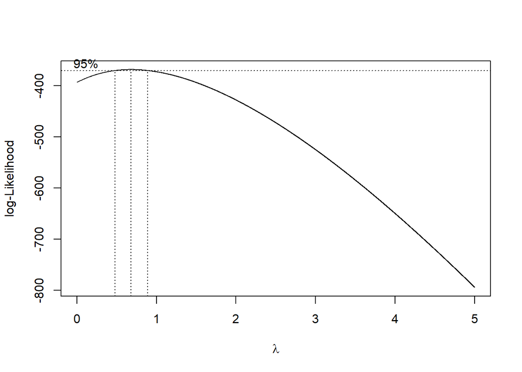

```r
index <- seq(1:200)

# Uji Box-Cox
bc <- boxcox(
  dtgab - min(dtgab) + 1 ~ index,
  lambda = seq(0, 5, by = 0.001)
)
```

```r
# Nilai lambda optimum (dibulatkan)
lambda <- bc$x[which.max(bc$y)]
lambda
```

```
[1] 0.679
```

```r
# Selang kepercayaan 95% untuk lambda
ci_lambda <- bc$x[bc$y > max(bc$y) - 0.5 * qchisq(0.95, 1)]

# Batas bawah dan batas atas
ci_lower <- min(ci_lambda)
ci_upper <- max(ci_lambda)

c(Batas_Bawah = ci_lower, Batas_Atas = ci_upper)
```

```
Batas_Bawah  Batas_Atas
      0.479       0.890
```

Hasil uji Box–Cox menunjukkan bahwa nilai λ optimum adalah 0,679 dengan interval kepercayaan 95% sebesar (0,479–0,890). Karena selang tersebut tidak memuat nilai λ = 1, maka dapat disimpulkan bahwa data tidak stasioner dalam ragam sehingga diperlukan transformasi.

### Transformasi Box–Cox

Transformasi Box–Cox atau transformasi pangkat digunakan untuk menangani deret yang tidak stasioner dalam ragam.

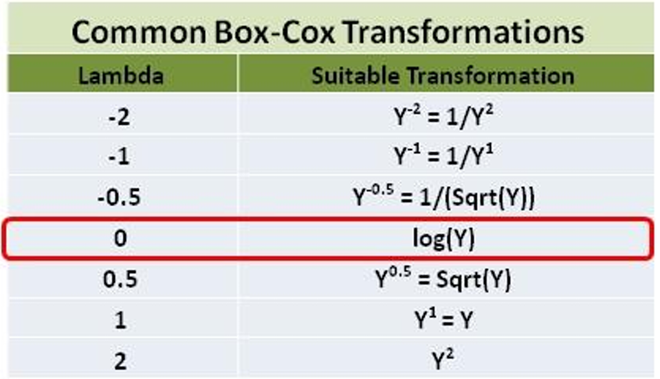

> *Catatan:*  
> Transformasi pangkat hanya dapat diterapkan pada data yang **bernilai positif**.  
> Apabila terdapat nilai nol atau negatif, maka suatu konstanta positif perlu ditambahkan pada seluruh data agar semuanya bernilai positif sebelum dilakukan transformasi.

```r
# Data digeser agar positif
y_shift <- dtgab - min(dtgab) + 1

# Transformasi Box-Cox dengan lambda ~ 0.5 (akar kuadrat)
y_bc <- y_shift^0.5
```

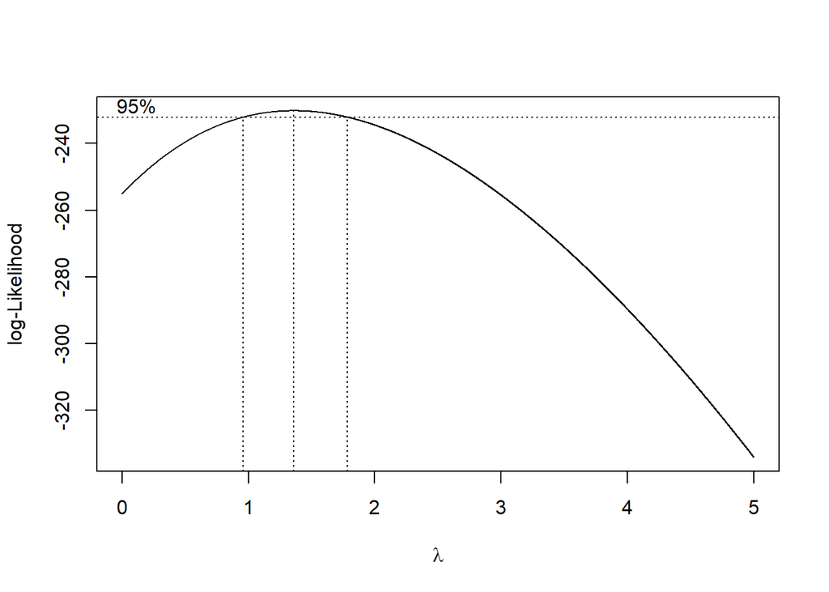

```r
index <- seq(1:200)

# Uji Box-Cox
bc <- boxcox(
  y_bc ~ index,
  lambda = seq(0, 5, by = 0.001)
)
```

```r
# Nilai lambda optimum (dibulatkan)
lambda <- bc$x[which.max(bc$y)]
lambda
```

```
[1] 1.359
```

```r
# Selang kepercayaan 95% untuk lambda
ci_lambda <- bc$x[bc$y > max(bc$y) - 0.5 * qchisq(0.95, 1)]

# Batas bawah dan batas atas
ci_lower <- min(ci_lambda)
ci_upper <- max(ci_lambda)

c(Batas_Bawah = ci_lower, Batas_Atas = ci_upper)
```

```
Batas_Bawah  Batas_Atas
      0.958       1.781
```

### Partisi Data

#### Bagian 1 :

```r
dtgab1 <- dtgab[80:200] |> ts()
mean(dtgab1)
```

```
[1] 1.863762
```

```r
var(dtgab1)
```

```
[1] 25.95595
```

#### Plot Time Series

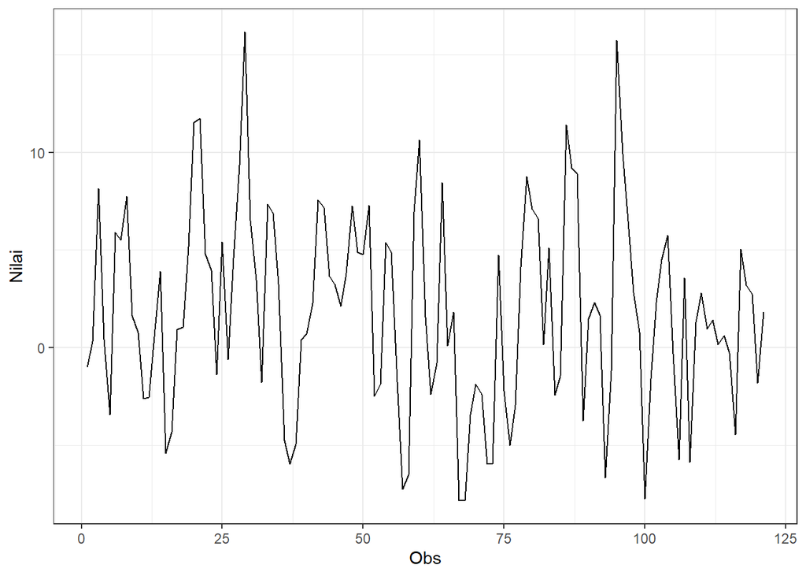

```r
dtgab1 |> as_tsibble() |>
  ggplot(aes(x = index, y = value)) +
  geom_line() + theme_bw() +
  xlab("Obs") + ylab("Nilai")
```

Berdasarkan plot time series tersebut, terlihat bahwa data cenderung stasioner dalam rataan, ditandain dengan tidak adanya trend dan musiman pada data, serta stasioner dalam ragam, ditandai dengan lebar pita yang cenderung sama pada plot tersebut

#### Plot ACF

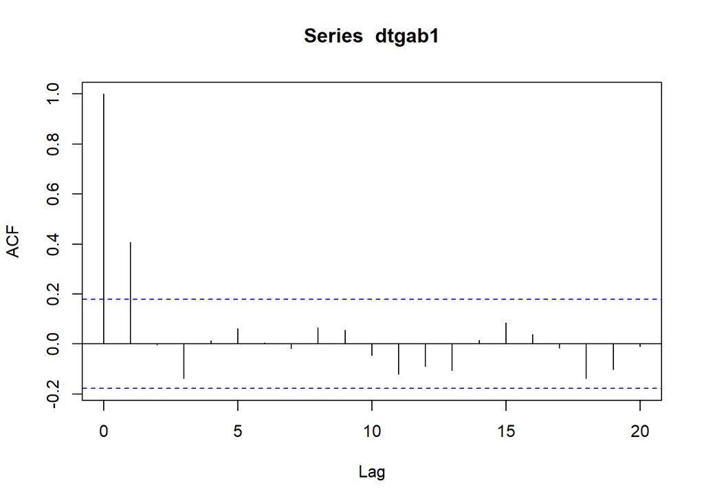

```r
acf(dtgab1)
```

#### Uji ADF

```r
adf.test(dtgab1)
```

```
    Augmented Dickey-Fuller Test

data:  dtgab1
Dickey-Fuller = -4.5366, Lag order = 4, p-value = 0.01
alternative hypothesis: stationary
```

$H_0$ : Data tidak stasioner dalam rataan

$H_1$ : Data stasioner dalam rataan

#### Plot Boxcox

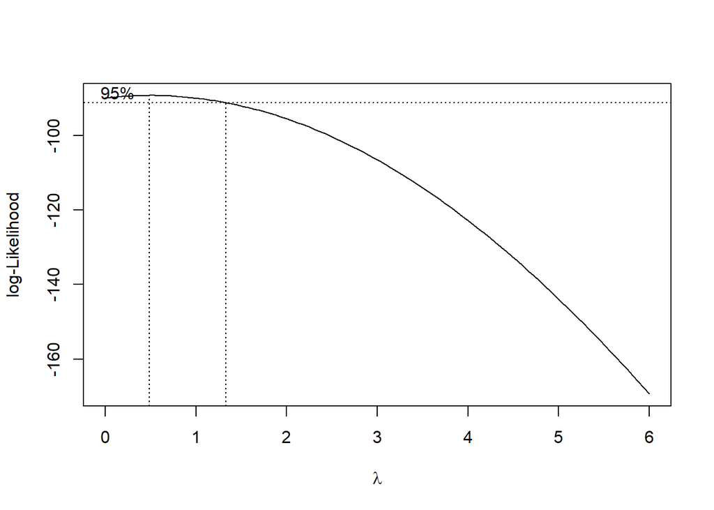

```r
index <- seq(80:200)
bc = boxcox(dtgab1+25~index, lambda = seq(0,6,by=1))
```

```r
#Nilai Rounded Lambda
lambda <- bc$x[which.max(bc$y)]
lambda
```

```
[1] 0.4848485
```

```r
#SK
bc$x[bc$y > max(bc$y) - 1/2 * qchisq(.95,1)]
```

```
 [1] 0.00000000 0.06060606 0.12121212 0.18181818 0.24242424 0.30303030
 [7] 0.36363636 0.42424242 0.48484848 0.54545455 0.60606061 0.66666667
[13] 0.72727273 0.78787879 0.84848485 0.90909091 0.96969697 1.03030303
[19] 1.09090909 1.15151515 1.21212121 1.27272727
```

#### Bagian 2

```r
dtgab2 <- dtgab[1:132] |> ts()
mean(dtgab2)
```

```
[1] 1.050091
```

```r
var(dtgab2)
```

```
[1] 11.85878
```

#### Plot Time Series

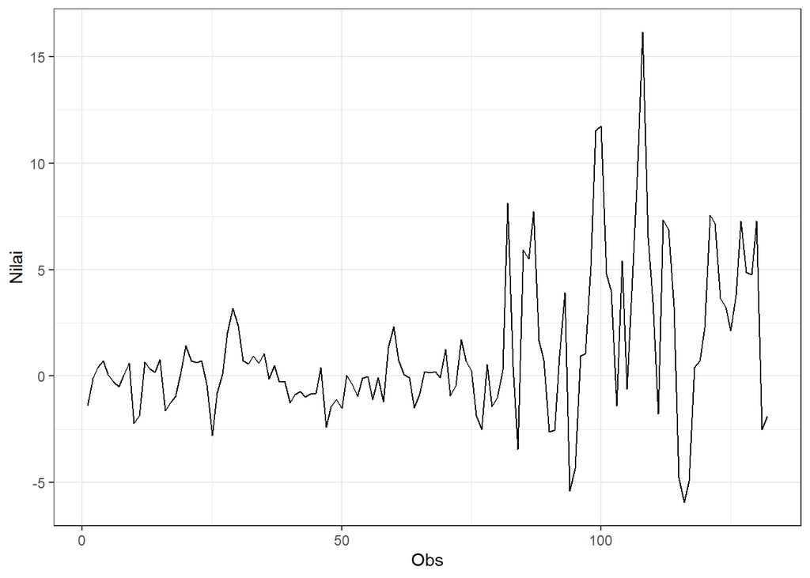

```r
dtgab2 |> as_tsibble() |>
  ggplot(aes(x = index, y = value)) +
  geom_line() + theme_bw() +
  xlab("Obs") + ylab("Nilai")
```

Berdasarkan plot data deret waktu tersebut, terlihat bahwa data stasioner dalam rataan, ditandai dengan data yang tidak menunjukkan adanya trend ataupun musiman, serta tidak stasioner dalam ragam ditandai dengan lebar pita pada plot yang cenderung berbeda di beberapa periode waktunya

#### Plot ACF

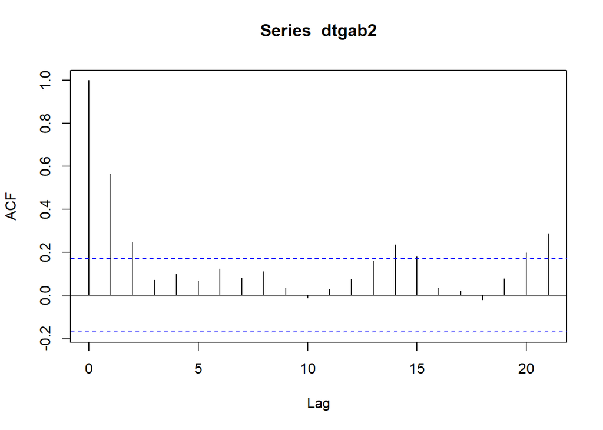

```r
acf(dtgab2)
```

Berdasarkan plot ACF tersebut, terlihat bahwa data stasioner dalam rataan ditandai dengan plot ACF yang *cuts off* pada lag ke 2

#### Uji ADF

```r
adf.test(dtgab2)
```

```
    Augmented Dickey-Fuller Test

data:  dtgab2
Dickey-Fuller = -4.1739, Lag order = 5, p-value = 0.01
alternative hypothesis: stationary
```

$H_0$ : Data tidak stasioner dalam rataan

$H_1$ : Data stasioner dalam rataan

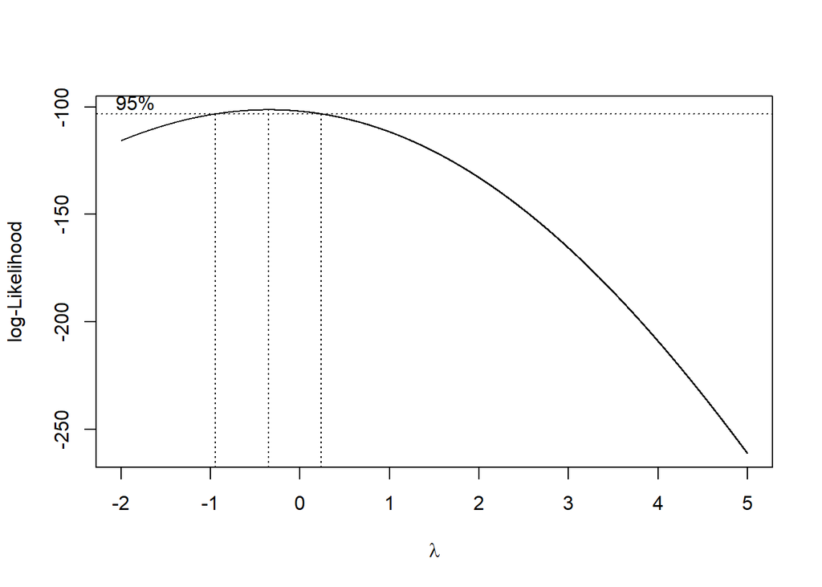

```r
index <- seq(1:132)

# Uji Box-Cox
bc <- boxcox(
  dtgab2 +15 ~ index,
  lambda = seq(-2, 5, by = 0.001)
)
```

```r
# Nilai lambda optimum (dibulatkan)
lambda <- bc$x[which.max(bc$y)]
lambda
```

```
[1] -0.35
```

```r
# Selang kepercayaan 95% untuk lambda
ci_lambda <- bc$x[bc$y > max(bc$y) - 0.5 * qchisq(0.95, 1)]

# Batas bawah dan batas atas
ci_lower <- min(ci_lambda)
ci_upper <- max(ci_lambda)

c(Batas_Bawah = ci_lower, Batas_Atas = ci_upper)
```

```
Batas_Bawah  Batas_Atas
     -0.944       0.236
```

## Tidak Stasioner dalam Rataan dan Ragam

Hal ini dapat disimulasikan dengan membangkitkan data yang tidak stasioner dalam ragam lalu membentuk trend menggunakan data tersebut

```r
set.seed(8990)
sd2 <- arima.sim(n=100, list(order=c(1,0,1),ar=c(.2), ma=.2), sd = 2)
sd6 <- arima.sim(n=100, list(order=c(1,0,1),ar=c(.2), ma=.2), sd = 6)
datagab <- c(sd2,sd6)
dt_rg <- startSpot + cumsum(datagab)  |> ts()
dt_rg <- dt_rg +100
```

### Plot Time Series

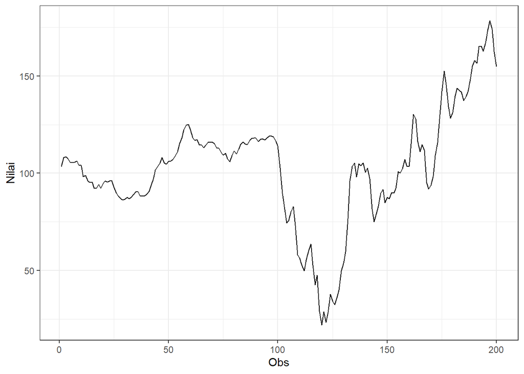

```r
dt_rg |> as_tsibble() |>
  ggplot(aes(x = index, y = value)) +
  geom_line() + theme_bw() +
  xlab("Obs") + ylab("Nilai")
```

Berdasarkan plot time series tersebut, terlihat bahwa data tidak stasioner dalam rataan, ditandai dengan adanya trend pada data dan tidak stasioner dalam ragam, ditandai dengan adanya perbedaan lebar pita pada plot

### Plot ACF

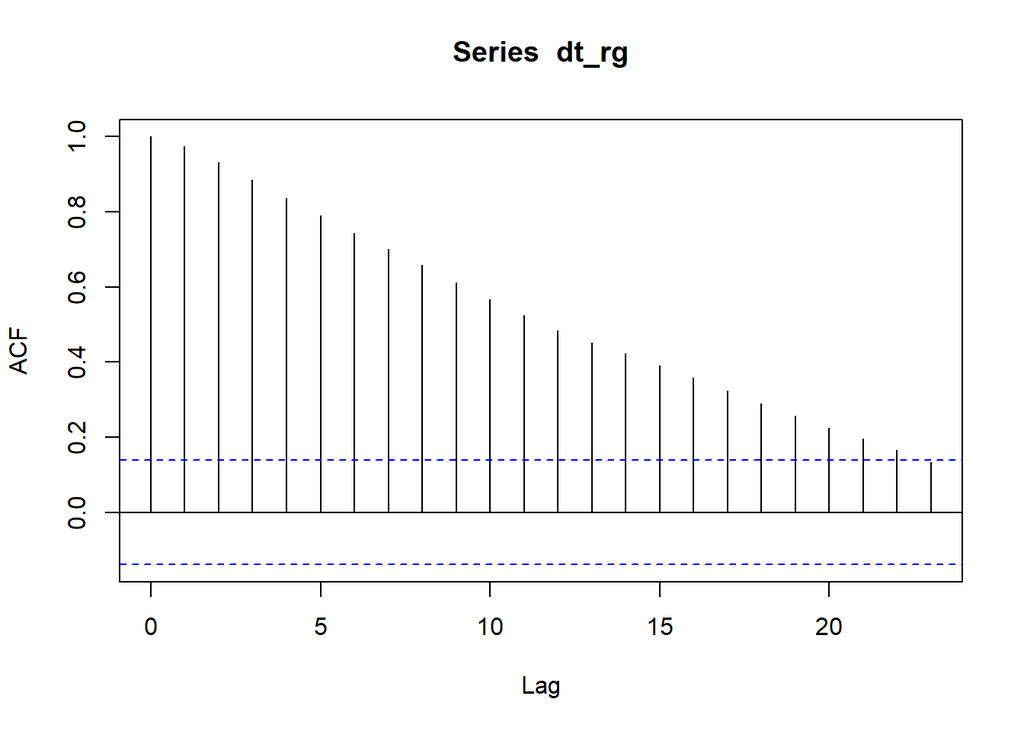

```r
acf(dt_rg)
```

Berdasarkan plot ACF, terlihat bahwa plot ACF pada data tersebut menurun secara perlahan (*tails off slowly*) yang menandakan data tidak stasioner dalam rataan

### Uji ADF

```r
adf.test(dt_rg)
```

```
    Augmented Dickey-Fuller Test

data:  dt_rg
Dickey-Fuller = -1.8362, Lag order = 5, p-value = 0.6447
alternative hypothesis: stationary
```

$H_0$ : Data tidak stasioner dalam rataan

$H_1$ : Data stasioner dalam rataan

Berdasarkan uji ADF tersebut, didapat *p-value* sebesar 0.6447 yang lebih besar dari taraf nyata 5% dan menandakan bahwa data tidak stasioner dalam rataan. Hal ini sesuai dengan hasil eksplorasi menggunakan plot time series dan plot ACF.

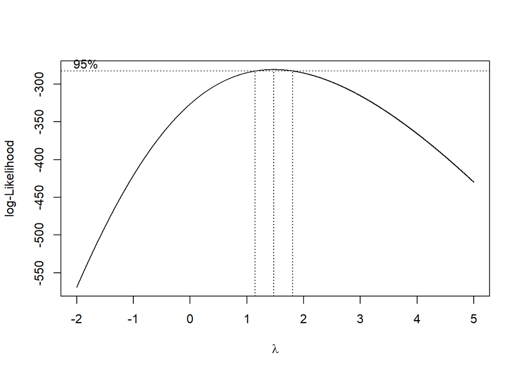

```r
index <- seq(1:200)

# Uji Box-Cox
bc <- boxcox(
  dt_rg ~ index,
  lambda = seq(-2, 5, by = 0.001)
)
```

```r
# Nilai lambda optimum (dibulatkan)
lambda <- bc$x[which.max(bc$y)]
lambda
```

```
[1] 1.47
```

```r
# Selang kepercayaan 95% untuk lambda
ci_lambda <- bc$x[bc$y > max(bc$y) - 0.5 * qchisq(0.95, 1)]

# Batas bawah dan batas atas
ci_lower <- min(ci_lambda)
ci_upper <- max(ci_lambda)

c(Batas_Bawah = ci_lower, Batas_Atas = ci_upper)
```

```
Batas_Bawah  Batas_Atas
      1.148       1.805
```

differencing

```r
# Differencing pertama pada postrend
dt_rg_diff1 <- diff(dt_rg, differences = 1)
```

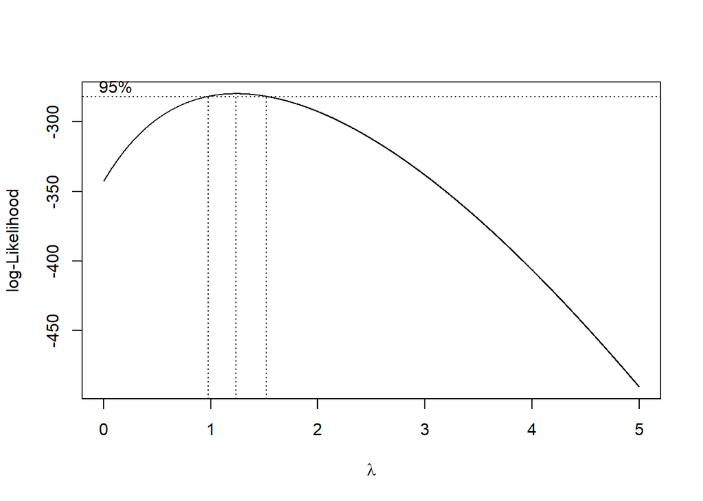

```r
index <- seq(1:199)

# Uji Box-Cox
bc <- boxcox(
  dt_rg_diff1 - min(dt_rg_diff1) + 1 ~ index,
  lambda = seq(0, 5, by = 0.001)
)
```

```r
# Nilai lambda optimum (dibulatkan)
lambda <- bc$x[which.max(bc$y)]
lambda
```

```
[1] 1.238
```

```r
# Selang kepercayaan 95% untuk lambda
ci_lambda <- bc$x[bc$y > max(bc$y) - 0.5 * qchisq(0.95, 1)]

# Batas bawah dan batas atas
ci_lower <- min(ci_lambda)
ci_upper <- max(ci_lambda)

c(Batas_Bawah = ci_lower, Batas_Atas = ci_upper)
```

```
Batas_Bawah  Batas_Atas
      0.978       1.517
```

### Partisi Data

#### Bagian 1

```r
dt_rg1 <- dt_rg[1:66] |> ts()
mean(dt_rg1)
```

```
[1] 101.2441
```

```r
var(dt_rg1)
```

```
[1] 118.5542
```

#### Plot Time Series

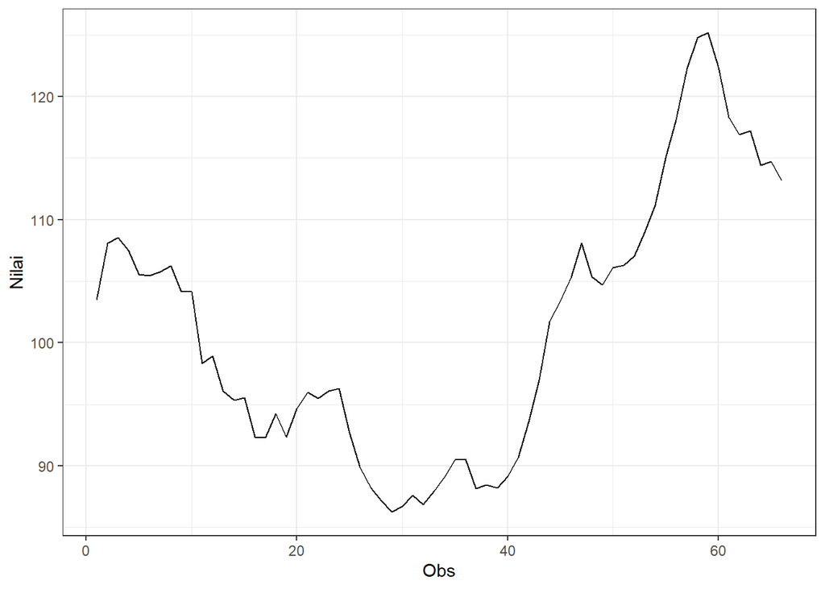

```r
dt_rg1 |> as_tsibble() |>
  ggplot(aes(x = index, y = value)) +
  geom_line() + theme_bw() +
  xlab("Obs") + ylab("Nilai")
```

Berdasarkan plot time series tersebut, terlihat bahwa data tidak stasioner dalam rataan karena masih terdapat tren pada data, namun cenderung stasioner dalam ragam karena memiliki lebar pita yang cenderung sama

#### Plot ACF

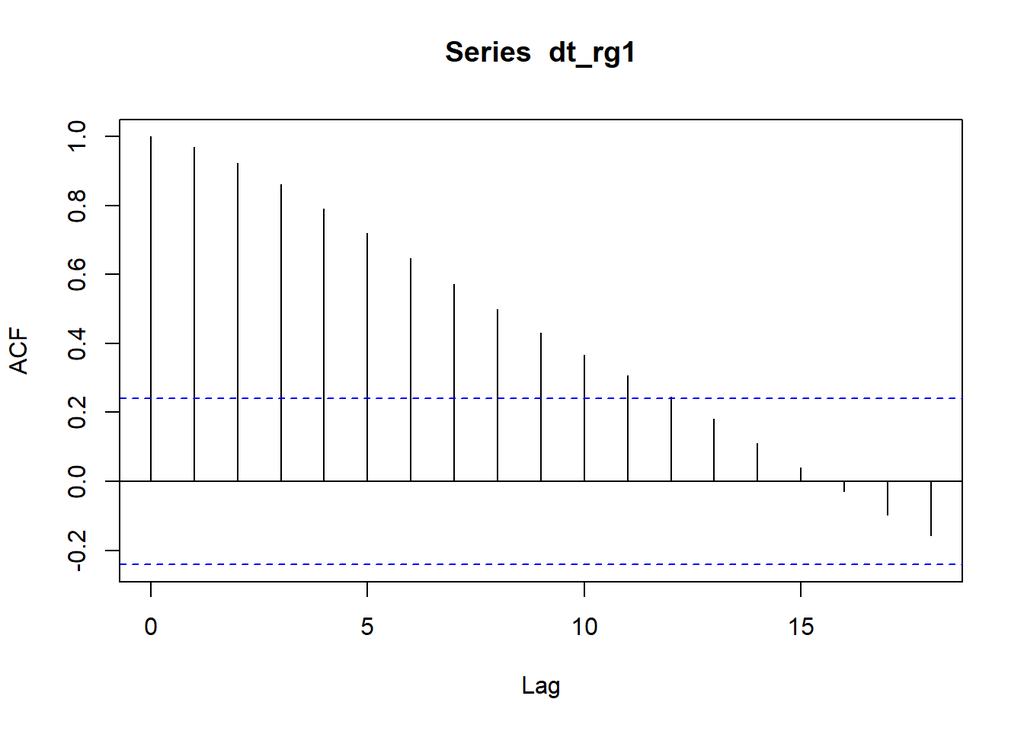

```r
acf(dt_rg1)
```

Berdasarkan plot ACF, terlihat bahwa plot ACF pada data tersebut menurun secara perlahan (*tails off slowly*) yang menandakan data tidak stasioner dalam rataan

#### Uji ADF

```r
adf.test(dt_rg1)
```

```
    Augmented Dickey-Fuller Test

data:  dt_rg1
Dickey-Fuller = -1.7373, Lag order = 4, p-value = 0.6816
alternative hypothesis: stationary
```

$H_0$ : Data tidak stasioner dalam rataan

$H_1$ : Data stasioner dalam rataan

Berdasarkan uji ADF tersebut, didapat *p-value* sebesar 0.6816 yang lebih besar dari taraf nyata 5% dan menandakan bahwa data tidak stasioner dalam rataan. Hal ini sesuai dengan hasil eksplorasi menggunakan plot time series dan plot ACF

#### Bagian 2

```r
dt_rg2 <- dt_rg[67:150] |> ts()
mean(dt_rg2)
```

```
[1] 87.36297
```

```r
var(dt_rg2)
```

```
[1] 913.2413
```

#### Plot Time Series

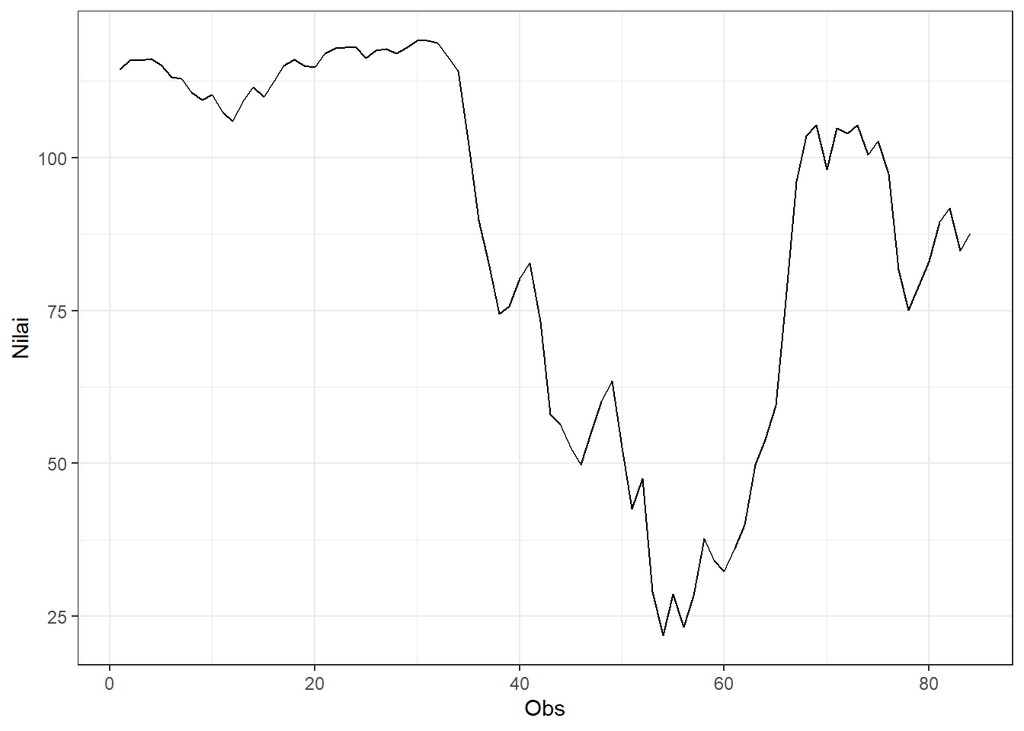

```r
dt_rg2 |> as_tsibble() |>
  ggplot(aes(x = index, y = value)) +
  geom_line() + theme_bw() +
  xlab("Obs") + ylab("Nilai")
```

Berdasarkan plot time series tersebut, terlihat bahwa data tidak stasioner dalam rataan karena masih terdapat tren pada data, dan tidak stasioner dalam ragam karena memiliki lebar pita yang cenderung tidak sama

#### Plot ACF

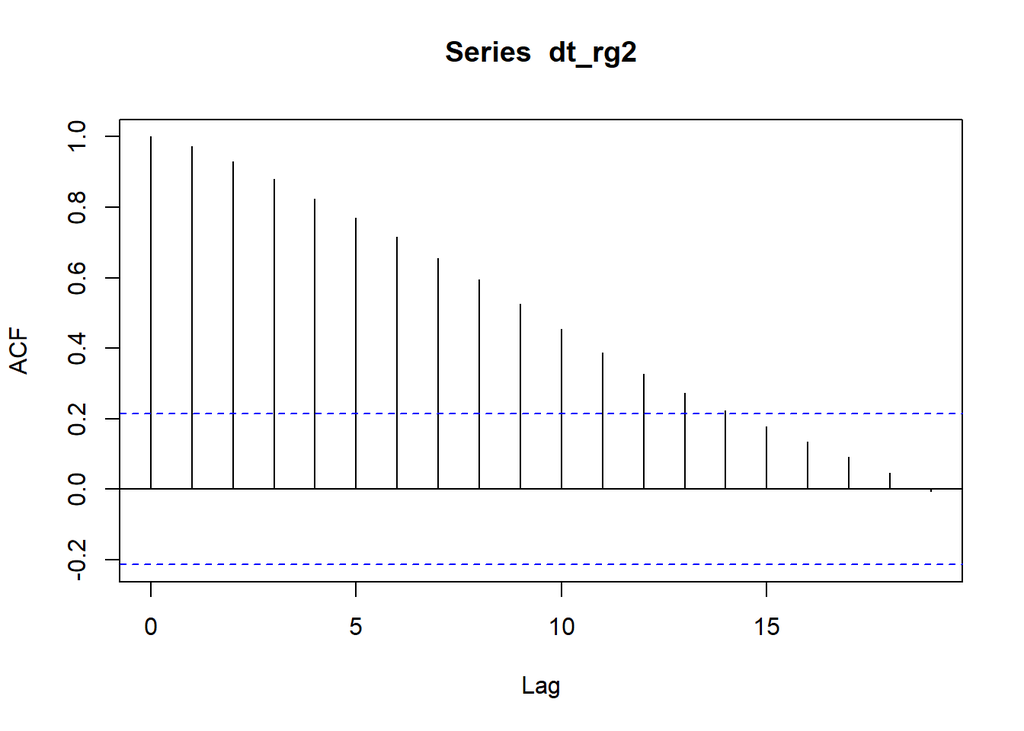

```r
acf(dt_rg2)
```

Berdasarkan plot ACF, terlihat bahwa plot ACF pada data tersebut menurun secara perlahan (*tails off slowly*) yang menandakan data tidak stasioner dalam rataan

#### Uji ADF

```r
adf.test(dt_rg2)
```

```
    Augmented Dickey-Fuller Test

data:  dt_rg2
Dickey-Fuller = -1.3767, Lag order = 4, p-value = 0.8315
alternative hypothesis: stationary
```

$H_0$ : Data tidak stasioner dalam rataan

$H_1$ : Data stasioner dalam rataan

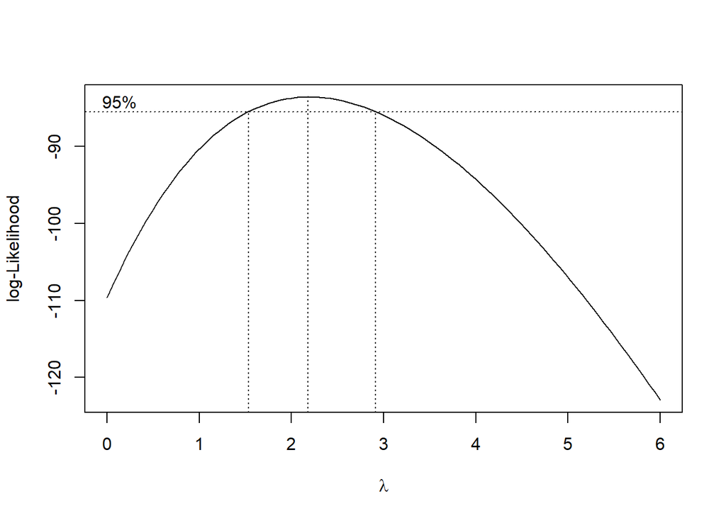

```r
index <- seq(1:84)

# Uji Box-Cox
bc <- boxcox(
  dt_rg2 ~ index,
  lambda = seq(0, 6, by = 1)
)
```

```r
# Nilai lambda optimum (dibulatkan)
lambda <- bc$x[which.max(bc$y)]
lambda
```

```
[1] 2.181818
```

```r
# Selang kepercayaan 95% untuk lambda
ci_lambda <- bc$x[bc$y > max(bc$y) - 0.5 * qchisq(0.95, 1)]

# Batas bawah dan batas atas
ci_lower <- min(ci_lambda)
ci_upper <- max(ci_lambda)

c(Batas_Bawah = ci_lower, Batas_Atas = ci_upper)
```

```
Batas_Bawah  Batas_Atas
   1.575758    2.909091
```

#### Bagian 3

```r
dt_rg3 <- dt_rg[151:200] |> ts()
mean(dt_rg3)
```

```
[1] 129.5688
```

```r
var(dt_rg3)
```

```
[1] 711.8398
```

#### Plot Time Series

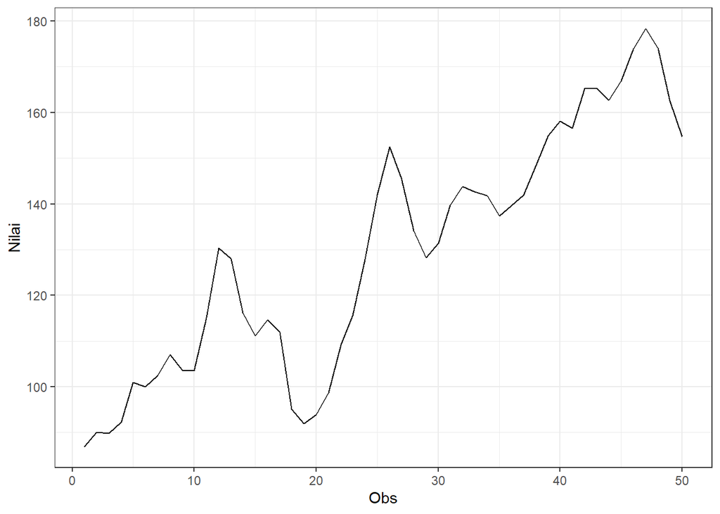

```r
dt_rg3 |> as_tsibble() |>
  ggplot(aes(x = index, y = value)) +
  geom_line() + theme_bw() +
  xlab("Obs") + ylab("Nilai")
```

Berdasarkan plot time series tersebut, terlihat bahwa data tidak stasioner dalam rataan karena masih terdapat tren pada data, namun cenderung stasioner dalam ragam karena memiliki lebar pita yang cenderung sama

#### Plot ACF

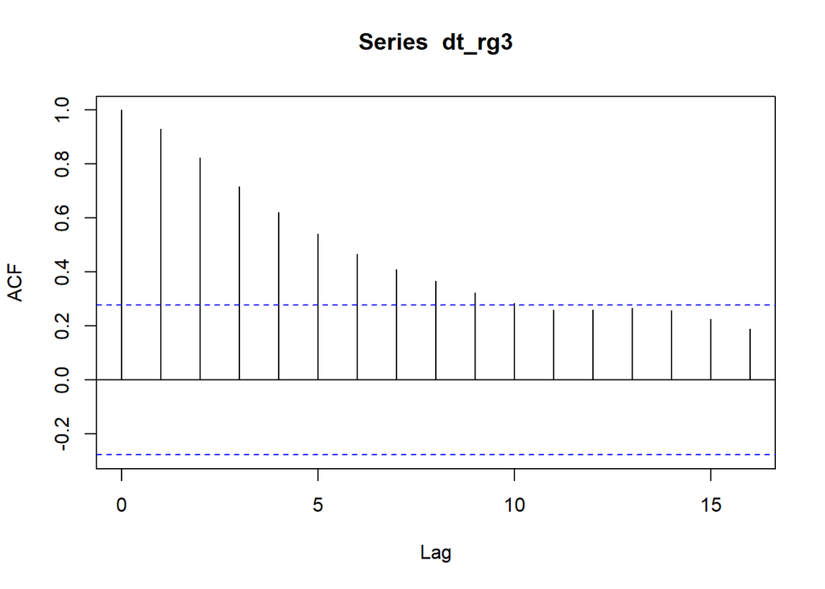

```r
acf(dt_rg3)
```

Berdasarkan plot ACF, terlihat bahwa plot ACF pada data tersebut menurun secara perlahan (*tails off slowly*)yang menandakan data tidak stasioner dalam rataan

#### Uji ADF

```r
tseries::adf.test(dt_rg3,k=5)
```

```
    Augmented Dickey-Fuller Test

data:  dt_rg3
Dickey-Fuller = -3.1927, Lag order = 5, p-value = 0.0984
alternative hypothesis: stationary
```

$H_0$ : Data tidak stasioner dalam rataan

$H_1$ : Data stasioner dalam rataan